# Linear Regression in Matrix Notation – starter code

This notebook explores linear regression from scratch on a tiny data set

```r
X = c(49, 69, 89, 99, 109)
y = c(124, 95, 71, 45, 18)
```

We can see that linear regression will fit this data fairly well if we plot the data with an abline.

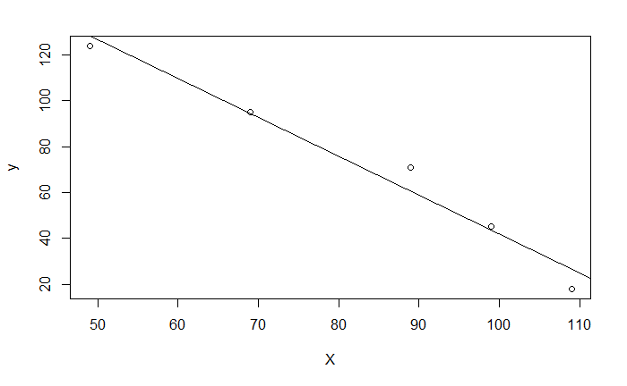

```r
plot(X, y)
abline(lm(y~X))
```

First, here is the solution for simple linear regression in algebraic notation:

$$\hat{b} = \bar{y} -
\hat{w}\bar{x}$$
$$\hat{w} =
\frac{\sum_{i=1}^{n} (x_i - \bar{x})(y_i - \bar{y}))}{\sum_{i=1}^{n}
(x_i - \bar{x})^2}$$
Find w-hat, the estimated parameter.

```r
x_mean = mean(X)
y_mean = mean(y)

w_hat = sum((X - x_mean) * (y - y_mean)) / sum((X - x_mean) ^ 2)


print(paste("w hat = ", w_hat))
```

```
[1] "w hat =  -1.6948275862069"
```

Find b and print it.

```r
b = y_mean - w_hat * x_mean

print(paste("b = ", b))
```

```
[1] "b =  211.270689655172"
```

Compare to lm()

```r
plot(X, y)
abline(lm(y~X))
```

[figure not shown]

```r
abline(y~w_hat * x + b)
```

### Matrix notation

$$\hat{w} = (X^TX)^{-1}X^Ty$$

Set up matrices. Matrix notation uses a column of 1s to represent b, or $w_0$

```r
X = matrix(cbind(1, X), ncol=2)
X
```

```
     [,1] [,2]
[1,]    1   49
[2,]    1   69
[3,]    1   89
[4,]    1   99
[5,]    1  109
```

First, perform

$$X^TX$$
X transpose will be a 2x5 matrix, X is 5x2. Therefore the result of the matrix multiplication will be a 2x2 matrix.

```r
result <- t(X) %*% X
result
```

```
     [,1]  [,2]
[1,]    5   415
[2,]  415 36765
```

Find the inverse. The solve() function is built into R.

```r
xt_x_inv <- solve(result)
xt_x_inv
```

```
            [,1]          [,2]
[1,]  3.16939655 -0.0357758621
[2,] -0.03577586  0.0004310345
```

We could use the following formula since it is a 2x2 matrix.

$$if A = \begin{bmatrix} a & b \\ c
& d \end{bmatrix}$$
Then A inverse is:

$$\frac{1}{ad - bc} \begin{bmatrix} d
& -b \\ -c & a \end{bmatrix}$$

```r
matrix2 <- matrix(c(result[2,2], -result[1,2], -result[2,1], result[1,1]), nrow=2)
const <- 1 / (result[1,1]*result[2,2] - result[1,2]*result[2,1])
inv2 <- const * matrix2
inv2
```

```
            [,1]          [,2]
[1,]  3.16939655 -0.0357758621
[2,] -0.03577586  0.0004310345
```

Now compute the second term.

X transpose is a 2x5 matrix, y is 5x1, so the product will be 2x1.

```r
# your code here

term2 <- t(X) %*% y
term2
```

```
      [,1]
[1,]   353
[2,] 25367
```

Now multiply the two terms.

```r
final <- inv2 %*% term2
final
```

```
           [,1]
[1,] 211.270690
[2,]  -1.694828
```

The same result is achieved from either notation. Note that the inverse was simple to compute here. Normally, computing the inverse is computationally complex, so R uses alternate methods to find the inverse.